```python
import numpy as np
import pandas as pd
import matplotlib.pyplot as plt
import seaborn as sns
from sklearn.metrics import roc_auc_score
from sklearn.linear_model import LogisticRegression
from sklearn.model_selection import train_test_split
from sklearn.metrics import roc_curve
from sklearn.linear_model import LogisticRegression
from sklearn.model_selection import cross_val_score
from sklearn.model_selection import KFold
from sklearn import metrics, svm
from sklearn.linear_model import LinearRegression
from sklearn import preprocessing
from sklearn import utils
from sklearn import metrics
from sklearn.preprocessing import StandardScaler
from sklearn.metrics import mean_squared_error
import statsmodels.api as sm
from tabulate import tabulate
import matplotlib.pyplot as plt
import seaborn as sns
%matplotlib inline
sns.set()
import warnings
warnings.filterwarnings('ignore')
rand_state= 1000
```

```python
df = pd.read_csv('boston_clean.csv')
```

# **EDA**

```python
df.head()
```

|  | CRIM | ZN | INDUS | CHAS | NOX | RM | AGE | DIS | RAD | TAX | PTRATIO | B | LSTAT | price |
| --- | --- | --- | --- | --- | --- | --- | --- | --- | --- | --- | --- | --- | --- | --- |
| 0 | 0.00632 | 18.0 | 2.31 | 0.0 | 0.538 | 6.575 | 65.2 | 4.0900 | 1.0 | 296.0 | 15.3 | 396.90 | 4.98 | 24.0 |
| 1 | 0.02731 | 0.0 | 7.07 | 0.0 | 0.469 | 6.421 | 78.9 | 4.9671 | 2.0 | 242.0 | 17.8 | 396.90 | 9.14 | 21.6 |
| 2 | 0.02729 | 0.0 | 7.07 | 0.0 | 0.469 | 7.185 | 61.1 | 4.9671 | 2.0 | 242.0 | 17.8 | 392.83 | 4.03 | 34.7 |
| 3 | 0.03237 | 0.0 | 2.18 | 0.0 | 0.458 | 6.998 | 45.8 | 6.0622 | 3.0 | 222.0 | 18.7 | 394.63 | 2.94 | 33.4 |
| 4 | 0.06905 | 0.0 | 2.18 | 0.0 | 0.458 | 7.147 | 54.2 | 6.0622 | 3.0 | 222.0 | 18.7 | 396.90 | 5.33 | 36.2 |

This dataset has 14 features.

```python
df.info()
```

```
<class 'pandas.core.frame.DataFrame'>
RangeIndex: 506 entries, 0 to 505
Data columns (total 14 columns):
 #   Column   Non-Null Count  Dtype
---  ------   --------------  -----
 0   CRIM     506 non-null    float64
 1   ZN       506 non-null    float64
 2   INDUS    506 non-null    float64
 3   CHAS     506 non-null    float64
 4   NOX      506 non-null    float64
 5   RM       506 non-null    float64
 6   AGE      506 non-null    float64
 7   DIS      506 non-null    float64
 8   RAD      506 non-null    float64
 9   TAX      506 non-null    float64
 10  PTRATIO  506 non-null    float64
 11  B        506 non-null    float64
 12  LSTAT    506 non-null    float64
 13  price    506 non-null    float64
dtypes: float64(14)
memory usage: 55.5 KB
```

:Attribute Information (in order):

- CRIM per capita crime rate by town
- ZN proportion of residential land zoned for lots over 25,000 sq.ft.
- INDUS proportion of non-retail business acres per town
- CHAS Charles River dummy variable (= 1 if tract bounds river; 0 otherwise)
- NOX nitric oxides concentration (parts per 10 million)
- RM average number of rooms per dwelling
- AGE proportion of owner-occupied units built prior to 1940
- DIS weighted distances to five Boston employment centres
- RAD index of accessibility to radial highways
- TAX full-value property-tax rate per 10,000 dollars
- PTRATIO pupil-teacher ratio by town
- B 1000(Bk - 0.63)^2 where Bk is the proportion of blacks by town
- LSTAT % lower status of the population
- MEDV Median value of owner-occupied homes in $1000's

Since we're using the clean version of this data set, the preprocessing has already been done. There are no missing values, weird variable types, or duplicate observations.

Let's start by looking at the statistical information for the different variables.

```python
df.describe().T
```

|  | count | mean | std | min | 25% | 50% | 75% | max |
| --- | --- | --- | --- | --- | --- | --- | --- | --- |
| CRIM | 506.0 | 3.613524 | 8.601545 | 0.00632 | 0.082045 | 0.25651 | 3.677082 | 88.9762 |
| ZN | 506.0 | 11.363636 | 23.322453 | 0.00000 | 0.000000 | 0.00000 | 12.500000 | 100.0000 |
| INDUS | 506.0 | 11.136779 | 6.860353 | 0.46000 | 5.190000 | 9.69000 | 18.100000 | 27.7400 |
| CHAS | 506.0 | 0.069170 | 0.253994 | 0.00000 | 0.000000 | 0.00000 | 0.000000 | 1.0000 |
| NOX | 506.0 | 0.554695 | 0.115878 | 0.38500 | 0.449000 | 0.53800 | 0.624000 | 0.8710 |
| RM | 506.0 | 6.284634 | 0.702617 | 3.56100 | 5.885500 | 6.20850 | 6.623500 | 8.7800 |
| AGE | 506.0 | 68.574901 | 28.148861 | 2.90000 | 45.025000 | 77.50000 | 94.075000 | 100.0000 |
| DIS | 506.0 | 3.795043 | 2.105710 | 1.12960 | 2.100175 | 3.20745 | 5.188425 | 12.1265 |
| RAD | 506.0 | 9.549407 | 8.707259 | 1.00000 | 4.000000 | 5.00000 | 24.000000 | 24.0000 |
| TAX | 506.0 | 408.237154 | 168.537116 | 187.00000 | 279.000000 | 330.00000 | 666.000000 | 711.0000 |
| PTRATIO | 506.0 | 18.455534 | 2.164946 | 12.60000 | 17.400000 | 19.05000 | 20.200000 | 22.0000 |
| B | 506.0 | 356.674032 | 91.294864 | 0.32000 | 375.377500 | 391.44000 | 396.225000 | 396.9000 |
| LSTAT | 506.0 | 12.653063 | 7.141062 | 1.73000 | 6.950000 | 11.36000 | 16.955000 | 37.9700 |
| price | 506.0 | 22.532806 | 9.197104 | 5.00000 | 17.025000 | 21.20000 | 25.000000 | 50.0000 |

A couple things to note - a sample size of just over 500 is pretty dismal. We should take all results with a grain of salt here. Other than that, the only fishy thing we notice is some outliers in the price variable.

Price seems like a good variable to use as a target in our regression models - let's take a look at it's distribution.

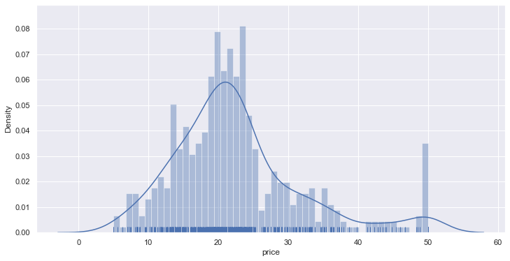

```python
plt.figure(figsize=(12,6))
sns.distplot(df['price'], kde=True, bins=50, rug=True)
plt.show()
```

This looks like a fairly normal distribution, but we're seeing those outliers on the right hand side. We'll want to keep that in mind through our analysis.

For the classification problem, it would be interesting to predict the variable CHAS, which is a dummy variable that tells us if the tract borders the Charles River. Let's take a look and see how balanced this variable is.

```python
pd.crosstab(df['CHAS'],df['CHAS'], normalize='all')*100
```

| CHAS | 0.0 | 1.0 |
| --- | --- | --- |
| 0.0 | 93.083004 | 0.000000 |
| 1.0 | 0.000000 | 6.916996 |

It looks like our target variable is unbalanced, so we should not trust accuracy scores - instead, we'll look at F1 scores to determine how well our classification models are doing.

Let's check out our correlation matrix before we start running the models.

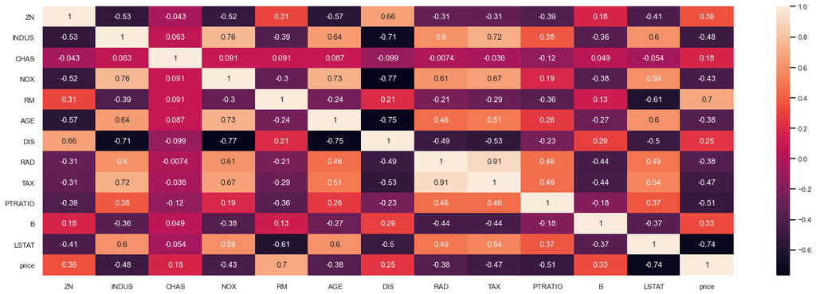

```python
sns.set(rc={'figure.figsize':(25,8)})
sns.set_context("talk", font_scale=0.7)
sns.heatmap(df.iloc[:,1:].corr(), annot=True)
```

There's a good bit of correlation going on between our variables, but nothing very surprising. The distance from the 5 Boston employment centres (DIS) is highly and negatively correlated with the proportion of non-retail business acres (INDUS), the nitric oxides concentration (NOX), and the proportion of homes built before 1940 (AGE). These are all things that we would expect to increase as we get closer to the city. As for the variables we're most interested in, we can see that price is highly and negatively correlated with the % of lower status of the population (LSTAT) and highly and positively correlated with the average number of rooms per dwelling (RM) which is also not surprising as we would expect more expensive homes to be bigger and in areas with a higher median income. Our classification target variable, CHAS, is not highly correlated with any other variable.

# **Regression Problem**

For our regression problem, we are going to use the supervised models to predict the price variable (median value of owner occupied homes in the tract) based on the other features in the dataset.

## Linear Regression

```python
df = pd.read_csv("boston_clean.csv")
```

```python
df.head()
```

|  | CRIM | ZN | INDUS | CHAS | NOX | RM | AGE | DIS | RAD | TAX | PTRATIO | B | LSTAT | price |
| --- | --- | --- | --- | --- | --- | --- | --- | --- | --- | --- | --- | --- | --- | --- |
| 0 | 0.00632 | 18.0 | 2.31 | 0.0 | 0.538 | 6.575 | 65.2 | 4.0900 | 1.0 | 296.0 | 15.3 | 396.90 | 4.98 | 24.0 |
| 1 | 0.02731 | 0.0 | 7.07 | 0.0 | 0.469 | 6.421 | 78.9 | 4.9671 | 2.0 | 242.0 | 17.8 | 396.90 | 9.14 | 21.6 |
| 2 | 0.02729 | 0.0 | 7.07 | 0.0 | 0.469 | 7.185 | 61.1 | 4.9671 | 2.0 | 242.0 | 17.8 | 392.83 | 4.03 | 34.7 |
| 3 | 0.03237 | 0.0 | 2.18 | 0.0 | 0.458 | 6.998 | 45.8 | 6.0622 | 3.0 | 222.0 | 18.7 | 394.63 | 2.94 | 33.4 |
| 4 | 0.06905 | 0.0 | 2.18 | 0.0 | 0.458 | 7.147 | 54.2 | 6.0622 | 3.0 | 222.0 | 18.7 | 396.90 | 5.33 | 36.2 |

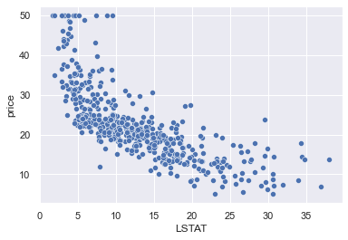

```python
sns.scatterplot(x='LSTAT', y='price', data=df)
plt.show()
```

```python
scaler=StandardScaler()
df_sc= scaler.fit_transform(df)
df_sc
```

```
array([[-0.41978194,  0.28482986, -1.2879095 , ...,  0.44105193,
        -1.0755623 ,  0.15968566],
       [-0.41733926, -0.48772236, -0.59338101, ...,  0.44105193,
        -0.49243937, -0.10152429],
       [-0.41734159, -0.48772236, -0.59338101, ...,  0.39642699,
        -1.2087274 ,  1.32424667],
       ...,
       [-0.41344658, -0.48772236,  0.11573841, ...,  0.44105193,
        -0.98304761,  0.14880191],
       [-0.40776407, -0.48772236,  0.11573841, ...,  0.4032249 ,
        -0.86530163, -0.0579893 ],
       [-0.41500016, -0.48772236,  0.11573841, ...,  0.44105193,
        -0.66905833, -1.15724782]])
```

```python
df_sc = pd.DataFrame(df_sc, columns=df.columns)
df_sc.head()
```

|  | CRIM | ZN | INDUS | CHAS | NOX | RM | AGE | DIS | RAD | TAX | PTRATIO | B | LSTAT | price |
| --- | --- | --- | --- | --- | --- | --- | --- | --- | --- | --- | --- | --- | --- | --- |
| 0 | -0.419782 | 0.284830 | -1.287909 | -0.272599 | -0.144217 | 0.413672 | -0.120013 | 0.140214 | -0.982843 | -0.666608 | -1.459000 | 0.441052 | -1.075562 | 0.159686 |
| 1 | -0.417339 | -0.487722 | -0.593381 | -0.272599 | -0.740262 | 0.194274 | 0.367166 | 0.557160 | -0.867883 | -0.987329 | -0.303094 | 0.441052 | -0.492439 | -0.101524 |
| 2 | -0.417342 | -0.487722 | -0.593381 | -0.272599 | -0.740262 | 1.282714 | -0.265812 | 0.557160 | -0.867883 | -0.987329 | -0.303094 | 0.396427 | -1.208727 | 1.324247 |
| 3 | -0.416750 | -0.487722 | -1.306878 | -0.272599 | -0.835284 | 1.016303 | -0.809889 | 1.077737 | -0.752922 | -1.106115 | 0.113032 | 0.416163 | -1.361517 | 1.182758 |
| 4 | -0.412482 | -0.487722 | -1.306878 | -0.272599 | -0.835284 | 1.228577 | -0.511180 | 1.077737 | -0.752922 | -1.106115 | 0.113032 | 0.441052 | -1.026501 | 1.487503 |

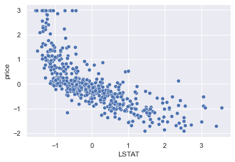

```python
sns.scatterplot(x='LSTAT', y='price', data=df_sc)
plt.show()
```

```python
y = df_sc['price']
X = df_sc.drop('price', axis=1)
```

```python
from sklearn.model_selection import train_test_split
X_train, X_test, y_train, y_test = train_test_split(X, y, test_size=0.2, random_state=rand_state)
X_train.head()
```

|  | CRIM | ZN | INDUS | CHAS | NOX | RM | AGE | DIS | RAD | TAX | PTRATIO | B | LSTAT |
| --- | --- | --- | --- | --- | --- | --- | --- | --- | --- | --- | --- | --- | --- |
| 300 | -0.415377 | 2.516647 | -1.298123 | -0.272599 | -1.336307 | 0.835371 | -0.752992 | 1.917048 | -0.523001 | -0.298373 | -1.690182 | 0.374827 | -0.922773 |
| 32 | -0.258993 | -0.487722 | -0.437258 | -0.272599 | -0.144217 | -0.476740 | 0.477404 | 0.092677 | -0.637962 | -0.601276 | 1.176466 | -1.360392 | 2.110588 |
| 181 | -0.412502 | -0.487722 | -1.266023 | -0.272599 | -0.576134 | -0.200356 | -0.226695 | -0.569085 | -0.752922 | -1.278354 | -0.303094 | 0.441052 | -0.448985 |
| 272 | -0.407181 | 0.370669 | -0.609431 | -0.272599 | -0.783454 | 0.360960 | -0.351157 | 0.058212 | -0.752922 | -1.100176 | 0.066796 | 0.419781 | -0.690084 |
| 477 | 1.327804 | -0.487722 | 1.015999 | -0.272599 | 0.512296 | -1.397069 | 1.021481 | -0.805438 | 1.661245 | 1.530926 | 0.806576 | -0.078878 | 1.718101 |

```python
X_test_wc = sm.add_constant(X_test)
X_train_wc = sm.add_constant(X_train)
```

```python
model = sm.OLS(y_train, X_train_wc).fit().summary()
```

OLS Regression Results

[output not shown]

|  | coef | std err | t | P>\|t\| | [0.025 | 0.975] |
| --- | --- | --- | --- | --- | --- | --- |
| const | 0.0011 | 0.025 | 0.043 | 0.966 | -0.049 | 0.051 |
| CRIM | -0.1197 | 0.031 | -3.811 | 0.000 | -0.181 | -0.058 |
| ZN | 0.1459 | 0.038 | 3.858 | 0.000 | 0.072 | 0.220 |
| INDUS | 0.0017 | 0.050 | 0.033 | 0.974 | -0.097 | 0.100 |
| CHAS | 0.0770 | 0.025 | 3.099 | 0.002 | 0.028 | 0.126 |
| NOX | -0.2605 | 0.051 | -5.072 | 0.000 | -0.361 | -0.160 |
| RM | 0.2578 | 0.035 | 7.341 | 0.000 | 0.189 | 0.327 |
| AGE | 0.0004 | 0.045 | 0.008 | 0.993 | -0.088 | 0.089 |
| DIS | -0.4063 | 0.052 | -7.805 | 0.000 | -0.509 | -0.304 |
| RAD | 0.2949 | 0.069 | 4.283 | 0.000 | 0.160 | 0.430 |
| TAX | -0.1984 | 0.075 | -2.639 | 0.009 | -0.346 | -0.051 |
| PTRATIO | -0.2475 | 0.033 | -7.475 | 0.000 | -0.313 | -0.182 |
| B | 0.0834 | 0.030 | 2.818 | 0.005 | 0.025 | 0.142 |
| LSTAT | -0.3925 | 0.042 | -9.382 | 0.000 | -0.475 | -0.310 |

| Omnibus: | 124.298 | Durbin-Watson: | 1.948 |
| --- | --- | --- | --- |
| Prob(Omnibus): | 0.000 | Jarque-Bera (JB): | 440.531 |
| Skew: | 1.357 | Prob(JB): | 2.19e-96 |
| Kurtosis: | 7.337 | Cond. No. | 9.67 |

Notes:  
[1] Standard Errors assume that the covariance matrix of the errors is correctly specified.

```python
from statsmodels.tools.eval_measures import rmse
```

```python
yhat = model.predict(X_test_wc)
```

```python
from statsmodels.tools.eval_measures import rmse
rmse = rmse(y_test, yhat)
rmse
```

```
0.5558427619365315
```

## Polynomial Regression

```python
scaler=StandardScaler()
df_sc= scaler.fit_transform(df)
```

```python
df_sc = pd.DataFrame(df_sc, columns=df.columns)
df_sc.head()
```

|  | CRIM | ZN | INDUS | CHAS | NOX | RM | AGE | DIS | RAD | TAX | PTRATIO | B | LSTAT | price |
| --- | --- | --- | --- | --- | --- | --- | --- | --- | --- | --- | --- | --- | --- | --- |
| 0 | -0.419782 | 0.284830 | -1.287909 | -0.272599 | -0.144217 | 0.413672 | -0.120013 | 0.140214 | -0.982843 | -0.666608 | -1.459000 | 0.441052 | -1.075562 | 0.159686 |
| 1 | -0.417339 | -0.487722 | -0.593381 | -0.272599 | -0.740262 | 0.194274 | 0.367166 | 0.557160 | -0.867883 | -0.987329 | -0.303094 | 0.441052 | -0.492439 | -0.101524 |
| 2 | -0.417342 | -0.487722 | -0.593381 | -0.272599 | -0.740262 | 1.282714 | -0.265812 | 0.557160 | -0.867883 | -0.987329 | -0.303094 | 0.396427 | -1.208727 | 1.324247 |
| 3 | -0.416750 | -0.487722 | -1.306878 | -0.272599 | -0.835284 | 1.016303 | -0.809889 | 1.077737 | -0.752922 | -1.106115 | 0.113032 | 0.416163 | -1.361517 | 1.182758 |
| 4 | -0.412482 | -0.487722 | -1.306878 | -0.272599 | -0.835284 | 1.228577 | -0.511180 | 1.077737 | -0.752922 | -1.106115 | 0.113032 | 0.441052 | -1.026501 | 1.487503 |

```python
y = df_sc['price']
X = df_sc.drop('price', axis=1)
```

```python
from sklearn.preprocessing import PolynomialFeatures
features = PolynomialFeatures(degree=5)
```

```python
X = features.fit_transform(df_sc)
```

```python
X.shape
```

```
(506, 11628)
```

```python
from sklearn.model_selection import train_test_split
X_train, X_test, y_train, y_test = train_test_split(X, y, test_size=0.3, random_state=rand_state)
```

```python
polynomial_model = LinearRegression()
polynomial_model.fit(X_train,y_train)
```

```
LinearRegression()
```

```python
y_hat_te= polynomial_model.predict(X_test)
```

```python
df_predictions = pd.DataFrame({'y_test':y_test, 'y_hat_test':y_hat_te, 'resid': y_test - y_hat_te})
df_predictions.head()
```

|  | y_test | y_hat_test | resid |
| --- | --- | --- | --- |
| 483 | -0.079757 | -0.158194 | 0.078437 |
| 426 | -1.342272 | -1.239196 | -0.103075 |
| 22 | -0.798084 | -0.745760 | -0.052324 |
| 268 | 2.282016 | 1.985016 | 0.297001 |
| 371 | 2.989460 | 2.579442 | 0.410018 |

```python
from sklearn.metrics import mean_squared_error
from math import sqrt

rmse_test_poly = sqrt(mean_squared_error(y_test, y_hat_te))
rmse_test_poly
```

```
0.4523869807314716
```

```python
def my_polynomial_regression(poly_degree, X, y, test_size=0.3, rand_state=100):

    poly_features= PolynomialFeatures(degree=poly_degree)

    # transforms the existing features to higher degree features.
    X = poly_features.fit_transform(df_sc)

    X_train, X_test, y_train, y_test = train_test_split(X, y, test_size=0.3, random_state=rand_state)

    # fit the transformed features to Linear Regression
    polynomial_model = LinearRegression()
    polynomial_model.fit(X_train,y_train)


    # predicting on training data-set
    y_train_predicted= polynomial_model.predict(X_train)

    # predicting on test data-set
    y_test_predicted = polynomial_model.predict(X_test)

   # evaluating the model on training dataset
    MSE_train = round(np.mean(np.square(y_train - y_train_predicted)),2)
    RMSE_train = round(np.sqrt(MSE_train),2)


    # evaluating the model on test dataset
    MSE_test = round(np.mean(np.square(y_test - y_test_predicted)),2)
    RMSE_test = round(np.sqrt(MSE_test),7)



#     print("Traning model fit")
#     print("R2_train = {}".format(R2_train))

#     print("-------------------------------------------")
#     print("MSE_train = {}".format(MSE_train))
#     print("RMSE_train = {}".format(RMSE_train))

#     print("-------------------------------------------")
#     print("MSE_test = {}".format(MSE_test))
#     print("RMSE_test = {}".format(RMSE_test))

    return poly_degree, RMSE_train, RMSE_test
```

```python
returns= []
for i in range(1,10):
    returns.append(my_polynomial_regression(poly_degree=i, X=X,y=y))

output = pd.DataFrame(returns, columns=['Degree', 'RMSE_train', 'RMSE_test'])
output
```

|  | Degree | RMSE_train | RMSE_test |
| --- | --- | --- | --- |
| 0 | 1 | 0.0 | 0.000000 |
| 1 | 2 | 0.0 | 0.000000 |
| 2 | 3 | 0.0 | 0.000000 |
| 3 | 4 | 0.0 | 0.316228 |
| 4 | 5 | 0.0 | 0.964365 |
| 5 | 6 | 0.0 | 14.690133 |
| 6 | 7 | 0.0 | 94.277569 |
| 7 | 8 | 0.0 | 593.274717 |
| 8 | 9 | 0.0 | 5867.358026 |

```python
y = df_sc['price']
X = df_sc.drop('price', axis=1)
```

```python
from sklearn.preprocessing import PolynomialFeatures
features = PolynomialFeatures(degree=4)
```

```python
X = features.fit_transform(df_sc)
```

```python
X.shape
```

```
(506, 3060)
```

```python
from sklearn.model_selection import train_test_split
X_train, X_test, y_train, y_test = train_test_split(X, y, test_size=0.3, random_state=rand_state)
```

```python
polynomial_model = LinearRegression()
polynomial_model.fit(X_train,y_train)
```

```
LinearRegression()
```

```python
y_hat_te= polynomial_model.predict(X_test)
```

```python
df_predictions = pd.DataFrame({'y_test':y_test, 'y_hat_test':y_hat_te, 'resid': y_test - y_hat_te})
df_predictions.head()
```

|  | y_test | y_hat_test | resid |
| --- | --- | --- | --- |
| 483 | -0.079757 | -0.054507 | -0.025250 |
| 426 | -1.342272 | -1.319184 | -0.023087 |
| 22 | -0.798084 | -0.781962 | -0.016122 |
| 268 | 2.282016 | 2.395951 | -0.113934 |
| 371 | 2.989460 | 3.469949 | -0.480489 |

```python
from sklearn.metrics import mean_squared_error
from math import sqrt

rmse_test_poly = sqrt(mean_squared_error(y_test, y_hat_te))
rmse_test_poly
```

```
0.25308201348513987
```

```python
NMSE = cross_val_score(estimator = polynomial_model, X = X_train, y = y_train, cv = 10 , scoring="neg_mean_squared_error" )
```

```python
NMSE
```

```
array([-0.53497615, -0.01681739, -0.34259129, -1.65749859, -0.06748186,
       -0.02480449, -0.10519506, -0.03114666, -0.01306159, -0.15660637])
```

```python
RMSE_CV = np.sqrt(-NMSE).mean()
RMSE_CV
```

```
0.41619659838759515
```

After cross validation, we're getting an RMSE of 0.42.

## Penalized Regression

```python
from sklearn.linear_model import Ridge,RidgeCV, Lasso, LassoCV, ElasticNet, ElasticNetCV
```

```python
y = df_sc['price']
X = df_sc.drop('price', axis=1)
```

```python
from sklearn.model_selection import train_test_split
X_train, X_test, y_train, y_test = train_test_split(X, y, test_size=0.2, random_state=rand_state)
X_train.head()
```

|  | CRIM | ZN | INDUS | CHAS | NOX | RM | AGE | DIS | RAD | TAX | PTRATIO | B | LSTAT |
| --- | --- | --- | --- | --- | --- | --- | --- | --- | --- | --- | --- | --- | --- |
| 300 | -0.415377 | 2.516647 | -1.298123 | -0.272599 | -1.336307 | 0.835371 | -0.752992 | 1.917048 | -0.523001 | -0.298373 | -1.690182 | 0.374827 | -0.922773 |
| 32 | -0.258993 | -0.487722 | -0.437258 | -0.272599 | -0.144217 | -0.476740 | 0.477404 | 0.092677 | -0.637962 | -0.601276 | 1.176466 | -1.360392 | 2.110588 |
| 181 | -0.412502 | -0.487722 | -1.266023 | -0.272599 | -0.576134 | -0.200356 | -0.226695 | -0.569085 | -0.752922 | -1.278354 | -0.303094 | 0.441052 | -0.448985 |
| 272 | -0.407181 | 0.370669 | -0.609431 | -0.272599 | -0.783454 | 0.360960 | -0.351157 | 0.058212 | -0.752922 | -1.100176 | 0.066796 | 0.419781 | -0.690084 |
| 477 | 1.327804 | -0.487722 | 1.015999 | -0.272599 | 0.512296 | -1.397069 | 1.021481 | -0.805438 | 1.661245 | 1.530926 | 0.806576 | -0.078878 | 1.718101 |

```python
model_linear = LinearRegression()
model_ridge = Ridge()
model_lasso = Lasso()
model_net = ElasticNet()
```

```python
y_hat_linear= model_linear.fit(X_train, y_train).predict(X_test)
y_hat_ridge = model_ridge.fit(X_train, y_train).predict(X_test)
y_hat_lasso = model_lasso.fit(X_train, y_train).predict(X_test)
y_hat_net   = model_net.fit(X_train, y_train).predict(X_test)
```

```python
df_predictions = pd.DataFrame({'y_test':y_test,
                               'y_hat_linear':y_hat_linear,
                               'y_hat_ridge':y_hat_ridge,
                               'y_hat_lasso':y_hat_lasso,
                               'y_hat_net':y_hat_net})
df_predictions.head()
```

[output not shown]

```python
df.drop('price', axis=1, inplace=False).columns
```

```
Index(['CRIM', 'ZN', 'INDUS', 'CHAS', 'NOX', 'RM', 'AGE', 'DIS', 'RAD', 'TAX',
       'PTRATIO', 'B', 'LSTAT'],
      dtype='object')
```

```python
coefficients = pd.DataFrame({'Features':df.drop('price', axis=1, inplace=False).columns})
coefficients['model_lin']= model_linear.coef_
coefficients['model_ridge']= model_ridge.coef_
coefficients['model_lasso']= model_lasso.coef_
coefficients['model_net']= model_net.coef_
coefficients
```

[output not shown]

```python
ridgecv = RidgeCV()
ridgecv.fit(X_train, y_train)
ridgecv.alpha_
```

```
10.0
```

```python
alpha_ridge_opt = ridgecv.alpha_
```

```python
#Cross validation to find the optimal alpha for Lasso regression
lassocv = LassoCV()
lassocv.fit(X_train, y_train)
lassocv.alpha_
```

```
0.05620866406509918
```

```python
alpha_lasso_opt = lassocv.alpha_
```

```python
#Cross validation to find the optimal alpha for Elastic Net regression
elasticnetcv = ElasticNetCV()
elasticnetcv.fit(X_train, y_train)
elasticnetcv.alpha_
```

```
0.11241732813019838
```

```python
alpha_elasticnet_opt = elasticnetcv.alpha_
```

```python
#lets refit the models
```

```python
model_linear_opt = LinearRegression()
model_ridge_opt = Ridge(alpha=10)
model_lasso_opt = Lasso(alpha=0.010732138475800224)
model_net_opt = ElasticNet(alpha=0.010682821217946607)
y_hat_opt_linear= model_linear.fit(X_train, y_train).predict(X_test)
y_hat_opt_ridge = model_ridge_opt.fit(X_train, y_train).predict(X_test)
y_hat_opt_lasso = model_lasso_opt.fit(X_train, y_train).predict(X_test)
y_hat_opt_net   = model_net_opt.fit(X_train, y_train).predict(X_test)
df_predictions_optimal = pd.DataFrame({'y_test':y_test,
                               'y_hat_linear':y_hat_linear,
                               'y_hat_ridge':y_hat_opt_ridge,
                               'y_hat_lasso':y_hat_opt_lasso,
                               'y_hat_net':y_hat_opt_net})
df_predictions_optimal.head()
```

[output not shown]

This is looking much better. Let's find out which model is doing best using the RMSE for each.

```python
from sklearn.metrics import mean_squared_error
from math import sqrt

rmse_test_linear = sqrt(mean_squared_error(y_test, y_hat_linear))
rmse_test_linear
```

```
0.2358914334607074
```

```python
rmse_test_ridge = sqrt(mean_squared_error(y_test, y_hat_opt_ridge))
rmse_test_ridge
```

```
0.23514683687983262
```

```python
rmse_test_lasso = sqrt(mean_squared_error(y_test, y_hat_opt_lasso))
rmse_test_lasso
```

```
0.23289861924196065
```

```python
rmse_test_net = sqrt(mean_squared_error(y_test, y_hat_opt_net))
rmse_test_net
```

```
0.23341814041925552
```

```python
output = pd.DataFrame(columns=['RMSE_test'], index=['Linear', 'Ridge', 'Lasso', 'E. Net'])
output['RMSE_test']=rmse_test_linear, rmse_test_ridge, rmse_test_lasso, rmse_test_net
output
```

|  | RMSE_test |
| --- | --- |
| Linear | 0.235891 |
| Ridge | 0.235147 |
| Lasso | 0.232899 |
| E. Net | 0.233418 |

The models are close but Lasso has the smallest RMSE.

Let's plot the coefficients vs alphas for each of the penalized regression models and see what's happening with each as we increase alpha.

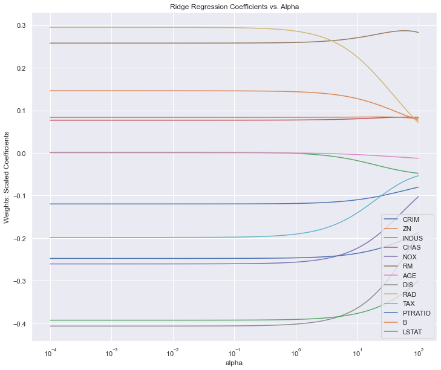

```python
alpha_ridge = 10**np.linspace(-4,2,100)
ridge = Ridge()
coefs_ridge = []

for i in alpha_ridge:
    ridge.set_params(alpha = i)
    ridge.fit(X_train, y_train)
    coefs_ridge.append(ridge.coef_)

np.shape(coefs_ridge)

plt.figure(figsize=(12,10))
ax = plt.gca()
ax.plot(alpha_ridge, coefs_ridge)
ax.set_xscale('log')
plt.axis('tight')
plt.xlabel('alpha')
plt.ylabel('Weights: Scaled Coefficients')
plt.title('Ridge Regression Coefficients vs. Alpha')
plt.legend(df.drop('price',axis=1, inplace=False).columns)

plt.show()
```

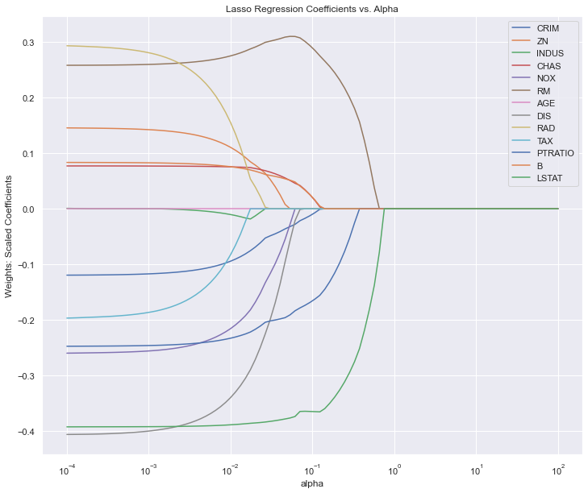

```python
alpha_lasso = 10**np.linspace(-4,2,100)
lasso = Lasso()
coefs_lasso = []

for i in alpha_lasso:
    lasso.set_params(alpha = i)
    lasso.fit(X_train, y_train)
    coefs_lasso.append(lasso.coef_)

np.shape(coefs_lasso)

plt.figure(figsize=(12,10))
ax = plt.gca()
ax.plot(alpha_lasso, coefs_lasso)
ax.set_xscale('log')
plt.axis('tight')
plt.xlabel('alpha')
plt.ylabel('Weights: Scaled Coefficients')
plt.title('Lasso Regression Coefficients vs. Alpha')
plt.legend(df.drop('price',axis=1, inplace=False).columns)

plt.show()
```

As we can see from this graph, most variables are staying somewhat constant until alpha = 10^(-3) with LSTAT and RM being the longest ones.

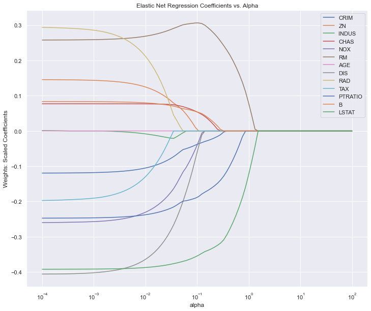

```python
alpha_elasticnet = 10**np.linspace(-4,2,100)

elasticnet = ElasticNet()
coefs_elasticnet = []

for i in alpha_elasticnet:
    elasticnet.set_params(alpha = i)
    elasticnet.fit(X_train, y_train)
    coefs_elasticnet.append(elasticnet.coef_)

np.shape(coefs_elasticnet)

plt.figure(figsize=(12,10))
ax = plt.gca()
ax.plot(alpha_elasticnet, coefs_elasticnet)
ax.set_xscale('log')
plt.axis('tight')
plt.xlabel('alpha')
plt.ylabel('Weights: Scaled Coefficients')
plt.title('Elastic Net Regression Coefficients vs. Alpha')
plt.legend(df.drop('price',axis=1, inplace=False).columns)

plt.show()
```

## KNN Regression

```python
df = pd.read_csv("boston_clean.csv")
```

```python
scaler=StandardScaler()
df_sc= scaler.fit_transform(df)
```

```python
df_sc = pd.DataFrame(df_sc, columns=df.columns)
df_sc.head()
```

|  | CRIM | ZN | INDUS | CHAS | NOX | RM | AGE | DIS | RAD | TAX | PTRATIO | B | LSTAT | price |
| --- | --- | --- | --- | --- | --- | --- | --- | --- | --- | --- | --- | --- | --- | --- |
| 0 | -0.419782 | 0.284830 | -1.287909 | -0.272599 | -0.144217 | 0.413672 | -0.120013 | 0.140214 | -0.982843 | -0.666608 | -1.459000 | 0.441052 | -1.075562 | 0.159686 |
| 1 | -0.417339 | -0.487722 | -0.593381 | -0.272599 | -0.740262 | 0.194274 | 0.367166 | 0.557160 | -0.867883 | -0.987329 | -0.303094 | 0.441052 | -0.492439 | -0.101524 |
| 2 | -0.417342 | -0.487722 | -0.593381 | -0.272599 | -0.740262 | 1.282714 | -0.265812 | 0.557160 | -0.867883 | -0.987329 | -0.303094 | 0.396427 | -1.208727 | 1.324247 |
| 3 | -0.416750 | -0.487722 | -1.306878 | -0.272599 | -0.835284 | 1.016303 | -0.809889 | 1.077737 | -0.752922 | -1.106115 | 0.113032 | 0.416163 | -1.361517 | 1.182758 |
| 4 | -0.412482 | -0.487722 | -1.306878 | -0.272599 | -0.835284 | 1.228577 | -0.511180 | 1.077737 | -0.752922 | -1.106115 | 0.113032 | 0.441052 | -1.026501 | 1.487503 |

```python
df_sc['CHAS']=df['CHAS']
df_sc.head(3)
```

|  | CRIM | ZN | INDUS | CHAS | NOX | RM | AGE | DIS | RAD | TAX | PTRATIO | B | LSTAT | price |
| --- | --- | --- | --- | --- | --- | --- | --- | --- | --- | --- | --- | --- | --- | --- |
| 0 | -0.419782 | 0.284830 | -1.287909 | 0.0 | -0.144217 | 0.413672 | -0.120013 | 0.140214 | -0.982843 | -0.666608 | -1.459000 | 0.441052 | -1.075562 | 0.159686 |
| 1 | -0.417339 | -0.487722 | -0.593381 | 0.0 | -0.740262 | 0.194274 | 0.367166 | 0.557160 | -0.867883 | -0.987329 | -0.303094 | 0.441052 | -0.492439 | -0.101524 |
| 2 | -0.417342 | -0.487722 | -0.593381 | 0.0 | -0.740262 | 1.282714 | -0.265812 | 0.557160 | -0.867883 | -0.987329 | -0.303094 | 0.396427 | -1.208727 | 1.324247 |

```python
y = df_sc['price']
X = df_sc.drop('price', axis=1)

from sklearn.model_selection import train_test_split
X_train, X_test, y_train, y_test = train_test_split(X, y, test_size=0.2, random_state=rand_state)
```

```python
X_train.head()
```

|  | CRIM | ZN | INDUS | CHAS | NOX | RM | AGE | DIS | RAD | TAX | PTRATIO | B | LSTAT |
| --- | --- | --- | --- | --- | --- | --- | --- | --- | --- | --- | --- | --- | --- |
| 300 | -0.415377 | 2.516647 | -1.298123 | 0.0 | -1.336307 | 0.835371 | -0.752992 | 1.917048 | -0.523001 | -0.298373 | -1.690182 | 0.374827 | -0.922773 |
| 32 | -0.258993 | -0.487722 | -0.437258 | 0.0 | -0.144217 | -0.476740 | 0.477404 | 0.092677 | -0.637962 | -0.601276 | 1.176466 | -1.360392 | 2.110588 |
| 181 | -0.412502 | -0.487722 | -1.266023 | 0.0 | -0.576134 | -0.200356 | -0.226695 | -0.569085 | -0.752922 | -1.278354 | -0.303094 | 0.441052 | -0.448985 |
| 272 | -0.407181 | 0.370669 | -0.609431 | 0.0 | -0.783454 | 0.360960 | -0.351157 | 0.058212 | -0.752922 | -1.100176 | 0.066796 | 0.419781 | -0.690084 |
| 477 | 1.327804 | -0.487722 | 1.015999 | 0.0 | 0.512296 | -1.397069 | 1.021481 | -0.805438 | 1.661245 | 1.530926 | 0.806576 | -0.078878 | 1.718101 |

```python
from sklearn.neighbors import KNeighborsRegressor
```

```python
KNN_regression = KNeighborsRegressor(n_neighbors=5)
KNN_regression.fit(X_train, y_train)
```

```
KNeighborsRegressor()
```

```python
y_hat = KNN_regression.predict(X_test)
```

```python
predictions = pd.DataFrame({ 'y_test':y_test,'y_hat':y_hat})
predictions.head()
```

|  | y_test | y_hat |
| --- | --- | --- |
| 483 | -0.079757 | -0.155943 |
| 426 | -1.342272 | -0.898215 |
| 22 | -0.798084 | -0.878624 |
| 268 | 2.282016 | 2.092639 |
| 371 | 2.989460 | 0.190160 |

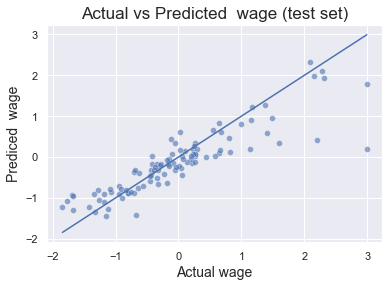

```python
sns.scatterplot(x=y_test, y=y_hat, alpha=0.6)
sns.lineplot(y_test, y_test)

plt.xlabel('Actual wage', fontsize=14)
plt.ylabel('Prediced  wage', fontsize=14)
plt.title('Actual vs Predicted  wage (test set)', fontsize=17)
plt.show()
```

```python
KNN_regression.score(X_test, y_test)
```

```
0.7597962696390848
```

```python
KNN_regression.score(X_train, y_train)
```

```
0.8973738175057072
```

```python
MSE_test = round(np.mean(np.square(y_test - y_hat)),2)
MSE_test
```

```
0.24
```

```python
RMSE_test = round(np.sqrt(MSE_test),2)
RMSE_test
```

```
0.49
```

```python
from sklearn.model_selection import cross_val_score
```

```python
NMSE = cross_val_score(estimator = KNN_regression, X = X_train, y = y_train, cv = 5 , scoring="neg_mean_squared_error" )
```

```python
MSE_CV = round(np.mean(-NMSE),4)
MSE_CV
```

```
0.2032
```

```python
RMSE_CV = round(np.sqrt(MSE_CV), 4)
RMSE_CV
```

```
0.4508
```

```python
RMSE_CV=[]
RMSE_test = []

k=40

for i in range(1,k):
    KNN_i = KNeighborsRegressor(n_neighbors=i)
    KNN_i.fit(X_train, y_train)
    RMSE_i = np.sqrt(np.mean(-1*cross_val_score(estimator = KNN_i, X = X_train, y = y_train, cv = 10 , scoring="neg_mean_squared_error" )))
    RMSE_CV.append(RMSE_i)

    RMSE_test.append(np.sqrt(np.mean(np.square(y_test - KNN_i.predict(X_test)))))

optimal_k = pd.DataFrame({'RMSE_CV': np.round(RMSE_CV,2), 'RMSE_test':np.round(RMSE_test,2)}, index=range(1,k))
```

```python
optimal_k.head(10)
```

|  | RMSE_CV | RMSE_test |
| --- | --- | --- |
| 1 | 0.46 | 0.57 |
| 2 | 0.39 | 0.47 |
| 3 | 0.38 | 0.48 |
| 4 | 0.40 | 0.49 |
| 5 | 0.42 | 0.49 |
| 6 | 0.44 | 0.50 |
| 7 | 0.46 | 0.51 |
| 8 | 0.47 | 0.51 |
| 9 | 0.49 | 0.52 |
| 10 | 0.50 | 0.51 |

```python
np.argmin(optimal_k['RMSE_CV'])
```

```
2
```

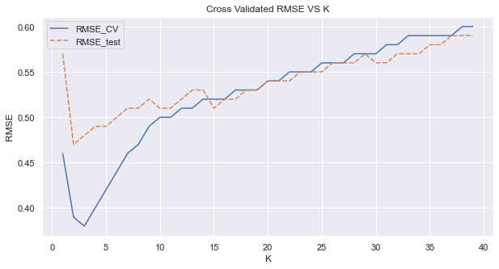

```python
plt.figure(figsize=(10,5))
sns.lineplot(data=optimal_k)
plt.title('Cross Validated RMSE VS K')
plt.xlabel('K')
plt.ylabel('RMSE')
plt.show()
```

```python
KNN_regression = KNeighborsRegressor(n_neighbors=2)
KNN_regression.fit(X_train, y_train)
```

```
KNeighborsRegressor(n_neighbors=2)
```

```python
y_hat = KNN_regression.predict(X_test)
```

```python
predictions = pd.DataFrame({ 'y_test':y_test,'y_hat':y_hat})
predictions.head()
```

|  | y_test | y_hat |
| --- | --- | --- |
| 483 | -0.079757 | -0.210362 |
| 426 | -1.342272 | -0.928689 |
| 22 | -0.798084 | -0.711014 |
| 268 | 2.282016 | 2.107877 |
| 371 | 2.989460 | 1.433084 |

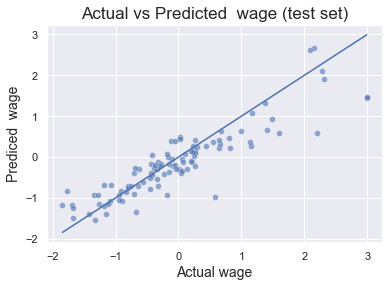

```python
sns.scatterplot(x=y_test, y=y_hat, alpha=0.6)
sns.lineplot(y_test, y_test)

plt.xlabel('Actual wage', fontsize=14)
plt.ylabel('Prediced  wage', fontsize=14)
plt.title('Actual vs Predicted  wage (test set)', fontsize=17)
plt.show()
```

```python
KNN_regression.score(X_test, y_test)
```

```
0.7859927783533742
```

```python
KNN_regression.score(X_train, y_train)
```

```
0.9422802804752287
```

```python
MSE_test = round(np.mean(np.square(y_test - y_hat)),2)
MSE_test
```

```
0.22
```

```python
RMSE_test = round(np.sqrt(MSE_test),2)
RMSE_test
```

```
0.47
```

## SVM Regression

```python
df = pd.read_csv("boston_clean.csv")
```

```python
from sklearn.preprocessing import StandardScaler
```

```python
scale = StandardScaler()
df_sc = scale.fit_transform(df)
df_sc = pd.DataFrame(df_sc, columns=df.columns)
```

```python
df_sc.head()
```

|  | CRIM | ZN | INDUS | CHAS | NOX | RM | AGE | DIS | RAD | TAX | PTRATIO | B | LSTAT | price |
| --- | --- | --- | --- | --- | --- | --- | --- | --- | --- | --- | --- | --- | --- | --- |
| 0 | -0.419782 | 0.284830 | -1.287909 | -0.272599 | -0.144217 | 0.413672 | -0.120013 | 0.140214 | -0.982843 | -0.666608 | -1.459000 | 0.441052 | -1.075562 | 0.159686 |
| 1 | -0.417339 | -0.487722 | -0.593381 | -0.272599 | -0.740262 | 0.194274 | 0.367166 | 0.557160 | -0.867883 | -0.987329 | -0.303094 | 0.441052 | -0.492439 | -0.101524 |
| 2 | -0.417342 | -0.487722 | -0.593381 | -0.272599 | -0.740262 | 1.282714 | -0.265812 | 0.557160 | -0.867883 | -0.987329 | -0.303094 | 0.396427 | -1.208727 | 1.324247 |
| 3 | -0.416750 | -0.487722 | -1.306878 | -0.272599 | -0.835284 | 1.016303 | -0.809889 | 1.077737 | -0.752922 | -1.106115 | 0.113032 | 0.416163 | -1.361517 | 1.182758 |
| 4 | -0.412482 | -0.487722 | -1.306878 | -0.272599 | -0.835284 | 1.228577 | -0.511180 | 1.077737 | -0.752922 | -1.106115 | 0.113032 | 0.441052 | -1.026501 | 1.487503 |

```python
y = df_sc['price']
X = df_sc.drop('price', axis=1) # becareful inplace= False

from sklearn.model_selection import train_test_split
X_train, X_test, y_train, y_test = train_test_split(X, y, test_size=0.3, random_state=rand_state)
```

```python
from sklearn.svm import SVR
```

```python
# Fitting SVM regression to the Training set
SVM_regression = SVR()
SVM_regression.fit(X_train, y_train)
```

```
SVR()
```

```python
# Predicting the Test set results
y_hat = SVM_regression.predict(X_test)
```

```python
predictions = pd.DataFrame({ 'y_test':y_test,'y_hat':y_hat})
predictions.head()
```

|  | y_test | y_hat |
| --- | --- | --- |
| 483 | -0.079757 | -0.031025 |
| 426 | -1.342272 | -0.730918 |
| 22 | -0.798084 | -0.679044 |
| 268 | 2.282016 | 2.249142 |
| 371 | 2.989460 | -0.174540 |

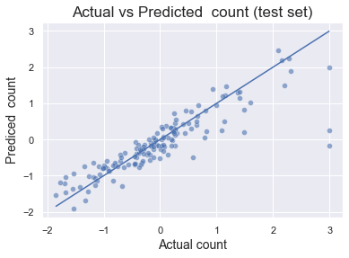

```python
sns.scatterplot(x=y_test, y=y_hat, alpha=0.6)
sns.lineplot(y_test, y_test)

plt.xlabel('Actual count', fontsize=14)
plt.ylabel('Prediced  count', fontsize=14)
plt.title('Actual vs Predicted  count (test set)', fontsize=17)
plt.show()
```

```python
SVM_regression.score(X_test, y_test)
```

```
0.7571233463882527
```

```python
MSE_test = round(np.mean(np.square(y_test - y_hat)),2)
RMSE_test = round(np.sqrt(MSE_test),2)
RMSE_test
```

```
0.47
```

```python
my_param_grid = {'C': [1,10,100], 'gamma': [1,0.1,0.01], 'kernel': ['rbf']}
```

```python
from sklearn.model_selection import GridSearchCV
```

```python
GridSearchCV(estimator=SVR(),param_grid= my_param_grid, refit = True, verbose=3, cv=5 )
```

```
GridSearchCV(cv=5, estimator=SVR(),
             param_grid={'C': [1, 10, 100], 'gamma': [1, 0.1, 0.01],
                         'kernel': ['rbf']},
             verbose=3)
```

```python
grid = GridSearchCV(estimator=SVR(),param_grid= my_param_grid, refit = True, verbose=2, cv=5 )
```

```python
grid.fit(X_train,y_train)
```

[output not shown]

[output not shown]

[output not shown]

[output cut: 8 more lines]

[output not shown]

```
[Parallel(n_jobs=1)]: Done  45 out of  45 | elapsed:    0.8s finished
```

```
GridSearchCV(cv=5, estimator=SVR(),
             param_grid={'C': [1, 10, 100], 'gamma': [1, 0.1, 0.01],
                         'kernel': ['rbf']},
             verbose=2)
```

```python
grid.best_params_
```

```
{'C': 10, 'gamma': 0.01, 'kernel': 'rbf'}
```

```python
grid.best_estimator_
```

```
SVR(C=10, gamma=0.01)
```

```python
y_hat_optimized = grid.predict(X_test)
```

```python
predictions['y_hat_optimized'] = y_hat_optimized
predictions.head()
```

|  | y_test | y_hat | y_hat_optimized |
| --- | --- | --- | --- |
| 483 | -0.079757 | -0.031025 | -0.008043 |
| 426 | -1.342272 | -0.730918 | -0.658849 |
| 22 | -0.798084 | -0.679044 | -0.661176 |
| 268 | 2.282016 | 2.249142 | 2.150375 |
| 371 | 2.989460 | -0.174540 | -0.184665 |

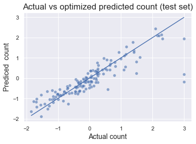

```python
sns.scatterplot(x=y_test, y=y_hat_optimized, alpha=0.6)
sns.lineplot(y_test, y_test)

plt.xlabel('Actual count', fontsize=14)
plt.ylabel('Prediced  count', fontsize=14)
plt.title('Actual vs optimized predicted count (test set)', fontsize=17)
plt.show()
```

```python
grid.score(X_test, y_test)
```

```
0.7550886482781349
```

```python
MSE_test_opt = round(np.mean(np.square(y_test - y_hat_optimized)),2)
RMSE_test_opt = round(np.sqrt(MSE_test_opt),2)
RMSE_test_opt
```

```
0.47
```

```python
from sklearn.model_selection import cross_val_score
```

```python
NMSE = cross_val_score(estimator = SVR(C=10, gamma=0.01), X = X_train, y = y_train, cv = 5 , scoring="neg_mean_squared_error" )
```

```python
MSE_CV = round(np.mean(-NMSE),4)
RMSE_CV = round(np.sqrt(MSE_CV),4)
RMSE_CV
```

```
0.3928
```